# index

Aimee Soto

2026-10-16

# Midterm

## Part I

```r
library(usethis)
library(git2r)
library(rvest)
library(tidyverse)
library(dplyr)
```

**Code explanation below each code chunk:**  
code space for libraries and any packages I may need

## Part II:

```r
communities <- read_html("https://en.wikipedia.org/wiki/Community_areas_of_Chicago")
```

Reads the page into r

```r
df_communities <- communities %>%
  html_element("table") %>%
  html_table%>%
  janitor::clean_names()
```

Calls the table from the datapage and uses the element function to scrape the table from the page into a neat table

```r
df_communities <- df_communities %>%
  slice(-(1), -(n()))

df_communities <- df_communities %>%
  rename(
    area_sqmi = area_9,
    area_km = area_9_2,
    density_sqmi = density,
    density_km = density_2
  )

df_communities$population <- gsub("[,]","", df_communities$population)
df_communities$population <-as.numeric(df_communities$population)
```

Cleans the dataframe by cleaning the column names, removing additional rows and removing the commas from population in order to change population data type to numeric

```r
print(df_communities[df_communities$no == 24, ])
```

```
## # A tibble: 1 × 7
##   no    name      population area_sqmi area_km density_sqmi density_km
##   <chr> <chr>          <dbl> <chr>     <chr>   <chr>        <chr>
## 1 24    West Town      88164 4.58      11.86   19,249.78    7,432.34
```

Prints the row for west town

```r
print(head(df_communities[order(df_communities$population, decreasing = TRUE), ], 5))
```

```
## # A tibble: 5 × 7
##   no    name            population area_sqmi area_km density_sqmi density_km
##   <chr> <chr>                <dbl> <chr>     <chr>   <chr>        <chr>
## 1 08    Near North Side     107331 2.74      7.1     39,171.9     15,124.27
## 2 06    Lake View           102827 3.12      8.08    32,957.37    12,724.84
## 3 25    Austin               97452 7.15      18.52   13,629.65    5,262.41
## 4 24    West Town            88164 4.58      11.86   19,249.78    7,432.34
## 5 02    West Ridge           78373 3.53      9.14    22,201.98    8,572.19
```

Prints the top 5 most populated areas in Chicago

```r
url <- read_html("https://books.toscrape.com/")
```

Reads the link in r

```r
books <- url %>%
  html_elements(".product_pod")
```

Sections where information is located

```r
titles <- books %>%
  html_elements("h3 a") %>%
  html_attr("title")
titles
```

```
##  [1] "A Light in the Attic"
##  [2] "Tipping the Velvet"
##  [3] "Soumission"
##  [4] "Sharp Objects"
##  [5] "Sapiens: A Brief History of Humankind"
##  [6] "The Requiem Red"
##  [7] "The Dirty Little Secrets of Getting Your Dream Job"
##  [8] "The Coming Woman: A Novel Based on the Life of the Infamous Feminist, Victoria Woodhull"
##  [9] "The Boys in the Boat: Nine Americans and Their Epic Quest for Gold at the 1936 Berlin Olympics"
## [10] "The Black Maria"
## [11] "Starving Hearts (Triangular Trade Trilogy, #1)"
## [12] "Shakespeare's Sonnets"
## [13] "Set Me Free"
## [14] "Scott Pilgrim's Precious Little Life (Scott Pilgrim #1)"
## [15] "Rip it Up and Start Again"
## [16] "Our Band Could Be Your Life: Scenes from the American Indie Underground, 1981-1991"
## [17] "Olio"
## [18] "Mesaerion: The Best Science Fiction Stories 1800-1849"
## [19] "Libertarianism for Beginners"
## [20] "It's Only the Himalayas"
```

Pulls the title names into a list

```r
price <- books%>%
  html_elements(".price_color")%>%
  html_text2()
price
```

```
##  [1] "£51.77" "£53.74" "£50.10" "£47.82" "£54.23" "£22.65" "£33.34" "£17.93"
##  [9] "£22.60" "£52.15" "£13.99" "£20.66" "£17.46" "£52.29" "£35.02" "£57.25"
## [17] "£23.88" "£37.59" "£51.33" "£45.17"
```

Pulls the price of the books into a list

```r
availability <- books %>%
  html_elements(".availability.instock")%>%
  html_text2()
availability
```

```
##  [1] "In stock" "In stock" "In stock" "In stock" "In stock" "In stock"
##  [7] "In stock" "In stock" "In stock" "In stock" "In stock" "In stock"
## [13] "In stock" "In stock" "In stock" "In stock" "In stock" "In stock"
## [19] "In stock" "In stock"
```

Pulls the avaliability of the book into a list

```r
books_20 <- tibble(
  title = titles,
  price = price,
  availability = availability
)
books_20
```

```
## # A tibble: 20 × 3
##    title                                                      price availability
##    <chr>                                                      <chr> <chr>
##  1 A Light in the Attic                                       £51.… In stock
##  2 Tipping the Velvet                                         £53.… In stock
##  3 Soumission                                                 £50.… In stock
##  4 Sharp Objects                                              £47.… In stock
##  5 Sapiens: A Brief History of Humankind                      £54.… In stock
##  6 The Requiem Red                                            £22.… In stock
##  7 The Dirty Little Secrets of Getting Your Dream Job         £33.… In stock
##  8 The Coming Woman: A Novel Based on the Life of the Infamo… £17.… In stock
##  9 The Boys in the Boat: Nine Americans and Their Epic Quest… £22.… In stock
## 10 The Black Maria                                            £52.… In stock
## 11 Starving Hearts (Triangular Trade Trilogy, #1)             £13.… In stock
## 12 Shakespeare's Sonnets                                      £20.… In stock
## 13 Set Me Free                                                £17.… In stock
## 14 Scott Pilgrim's Precious Little Life (Scott Pilgrim #1)    £52.… In stock
## 15 Rip it Up and Start Again                                  £35.… In stock
## 16 Our Band Could Be Your Life: Scenes from the American Ind… £57.… In stock
## 17 Olio                                                       £23.… In stock
## 18 Mesaerion: The Best Science Fiction Stories 1800-1849      £37.… In stock
## 19 Libertarianism for Beginners                               £51.… In stock
## 20 It's Only the Himalayas                                    £45.… In stock
```

Pulls all the elements into a table.  
**Bonus**

```r
rating <- books %>%
  html_elements(".star-rating")%>%
  html_attr("class")

rating <- gsub("star-rating", "", rating)
rating
```

```
##  [1] " Three" " One"   " One"   " Four"  " Five"  " One"   " Four"  " Three"
##  [9] " Four"  " One"   " Two"   " Four"  " Five"  " Five"  " Five"  " Three"
## [17] " One"   " One"   " Two"   " Two"
```

Add in rating column as a bonus

```r
rating_num <- c(" One" = 1, " Two" = 2, " Three" = 3, " Four" = 4, " Five" = 5)

rating <- as.numeric(rating_num[rating])
rating
```

```
##  [1] 3 1 1 4 5 1 4 3 4 1 2 4 5 5 5 3 1 1 2 2
```

Had to create a vector so the written numbers could know which numeric values they belonged to and assign them

```r
books_20_bonus <- tibble(
  title = titles,
  price = price,
  availability = availability,
  rating = rating
)
books_20_bonus
```

```
## # A tibble: 20 × 4
##    title                                               price availability rating
##    <chr>                                               <chr> <chr>         <dbl>
##  1 A Light in the Attic                                £51.… In stock          3
##  2 Tipping the Velvet                                  £53.… In stock          1
##  3 Soumission                                          £50.… In stock          1
##  4 Sharp Objects                                       £47.… In stock          4
##  5 Sapiens: A Brief History of Humankind               £54.… In stock          5
##  6 The Requiem Red                                     £22.… In stock          1
##  7 The Dirty Little Secrets of Getting Your Dream Job  £33.… In stock          4
##  8 The Coming Woman: A Novel Based on the Life of the… £17.… In stock          3
##  9 The Boys in the Boat: Nine Americans and Their Epi… £22.… In stock          4
## 10 The Black Maria                                     £52.… In stock          1
## 11 Starving Hearts (Triangular Trade Trilogy, #1)      £13.… In stock          2
## 12 Shakespeare's Sonnets                               £20.… In stock          4
## 13 Set Me Free                                         £17.… In stock          5
## 14 Scott Pilgrim's Precious Little Life (Scott Pilgri… £52.… In stock          5
## 15 Rip it Up and Start Again                           £35.… In stock          5
## 16 Our Band Could Be Your Life: Scenes from the Ameri… £57.… In stock          3
## 17 Olio                                                £23.… In stock          1
## 18 Mesaerion: The Best Science Fiction Stories 1800-1… £37.… In stock          1
## 19 Libertarianism for Beginners                        £51.… In stock          2
## 20 It's Only the Himalayas                             £45.… In stock          2
```

Final bonus table

## Part III

```r
library(httr)
library(jsonlite)
library(lubridate)
```

Loads the needed libraries

```r
url <- "https://data.cityofchicago.org/resource/v6vf-nfxy.json"

params <- list(
    community_area = "24",
    '$where' = "created_date >= '2026-01-01T00:00:00'",
    '$order' = "created_date DESC",
    '$limit' = 1000
    )

response <- GET(url, query = params)
```

Requests the data from the url and put parameters around certain variables, like filtering

```r
df <- fromJSON(content(response, "text", encoding = "UTF-8"))

print(nrow(df))
```

```
## [1] 1000
```

Prints the number of rows

```r
print(colnames(df))
```

```
##  [1] "sr_number"           "sr_type"             "sr_short_code"
##  [4] "created_department"  "owner_department"    "status"
##  [7] "origin"              "created_date"        "last_modified_date"
## [10] "street_address"      "city"                "state"
## [13] "zip_code"            "street_number"       "street_direction"
## [16] "street_name"         "street_type"         "duplicate"
## [19] "legacy_record"       "community_area"      "ward"
## [22] "electrical_district" "electricity_grid"    "police_sector"
## [25] "police_district"     "police_beat"         "precinct"
## [28] "created_hour"        "created_day_of_week" "created_month"
## [31] "x_coordinate"        "y_coordinate"        "latitude"
## [34] "longitude"           "location"            "parent_sr_number"
## [37] "closed_date"
```

Creates the dataframe from the information and prints the number of rows of the dataframe as well as the column names

```r
sr_counts <- df %>%
  count(sr_type, sort =TRUE)%>%
  slice_head( n = 10)%>%
  print()
```

```
##                                    sr_type   n
## 1                 Graffiti Removal Request 212
## 2             Rodent Baiting/Rat Complaint  63
## 3  Finance Parking Code Enforcement Review  39
## 4               Yard Waste Pick-Up Request  39
## 5                Sanitation Code Violation  31
## 6                  Alley Pothole Complaint  30
## 7                 Garbage Cart Maintenance  29
## 8              Dead Animal Pick-Up Request  28
## 9               Street Light Out Complaint  28
## 10                          Tree Emergency  28
```

Creates a count of different service requests types, put them in descending order and found the top ten most common.

**Interpret Answer:** This summary suggests that the neighborhood overwhelming needs graffiti removal more than any other service. The requests for graffiti removal is more than 3x that of the second most common request. This data cannot tell us which areas of West Town are the most common spots for these requests.

## Part IV

The variables:  
Gross rent as a Percentage of Household Income, “Total”: B25070_001E.  
Gross rent as a Percentage of Household Income, “50.0 percent or more”: B25070_010E.  
Median Household Income: B19013_001E.

```r
library(tidycensus)
library (tidyverse)
```

Loads any necessary libraries

```r
readRenviron("~/.Renviron")

ohio_counties <- get_acs(
  geography = "county",
  state = "OH",
  year = 2024,
  survey = "acs5",
  output = "wide",
  variables = c(
    gross_rent_total = "B25070_001",
    gross_rent_50pct = "B25070_010",
    median_household_income = "B19013_001"
  ),
)%>%
  select(
    GEOID, NAME, gross_rent_totalE, gross_rent_50pctE, median_household_incomeE
    )
ohio_counties
```

```
## # A tibble: 88 × 5
##    GEOID NAME         gross_rent_totalE gross_rent_50pctE median_household_inc…¹
##    <chr> <chr>                    <dbl>             <dbl>                  <dbl>
##  1 39001 Adams Count…              2954               559                  50264
##  2 39003 Allen Count…             13343              2537                  64038
##  3 39005 Ashland Cou…              4589               997                  69860
##  4 39007 Ashtabula C…              9556              2046                  57728
##  5 39009 Athens Coun…              9115              2751                  56001
##  6 39011 Auglaize Co…              4146               582                  78660
##  7 39013 Belmont Cou…              7176              1363                  57017
##  8 39015 Brown Count…              3911               686                  71270
##  9 39017 Butler Coun…             44147             10603                  81590
## 10 39019 Carroll Cou…              2385               297                  64835
## # ℹ 78 more rows
## # ℹ abbreviated name: ¹median_household_incomeE
```

Retrieves the three variables for each county in Ohio. Kept variables with “E” for estimates and removed “M” variables which stood for margin of error but doesnt seem to be necessary for the dataframe.Made the dataframe wide to have all three variables side-by-side

```r
ohio_counties <- ohio_counties%>%
  mutate(
    severe_burden_rate =
      (gross_rent_50pctE / gross_rent_totalE) * 100
    )
ohio_counties
```

```
## # A tibble: 88 × 6
##    GEOID NAME         gross_rent_totalE gross_rent_50pctE median_household_inc…¹
##    <chr> <chr>                    <dbl>             <dbl>                  <dbl>
##  1 39001 Adams Count…              2954               559                  50264
##  2 39003 Allen Count…             13343              2537                  64038
##  3 39005 Ashland Cou…              4589               997                  69860
##  4 39007 Ashtabula C…              9556              2046                  57728
##  5 39009 Athens Coun…              9115              2751                  56001
##  6 39011 Auglaize Co…              4146               582                  78660
##  7 39013 Belmont Cou…              7176              1363                  57017
##  8 39015 Brown Count…              3911               686                  71270
##  9 39017 Butler Coun…             44147             10603                  81590
## 10 39019 Carroll Cou…              2385               297                  64835
## # ℹ 78 more rows
## # ℹ abbreviated name: ¹median_household_incomeE
## # ℹ 1 more variable: severe_burden_rate <dbl>
```

Mutates the gross rent 50% variable divided gross rental total and multiples it by 100 to create a new variable called, “severe_burden_rate”

```r
ohio_counties <- ohio_counties%>%
  arrange(desc(severe_burden_rate))

ohio_counties
```

```
## # A tibble: 88 × 6
##    GEOID NAME         gross_rent_totalE gross_rent_50pctE median_household_inc…¹
##    <chr> <chr>                    <dbl>             <dbl>                  <dbl>
##  1 39009 Athens Coun…              9115              2751                  56001
##  2 39133 Portage Cou…             19481              5410                  75766
##  3 39061 Hamilton Co…            144332             35228                  72470
##  4 39145 Scioto Coun…              9115              2194                  50609
##  5 39093 Lorain Coun…             33139              7971                  73347
##  6 39017 Butler Coun…             44147             10603                  81590
##  7 39153 Summit Coun…             75130             17865                  71622
##  8 39029 Columbiana …             11300              2665                  58180
##  9 39035 Cuyahoga Co…            225378             53012                  64468
## 10 39031 Coshocton C…              4006               939                  55577
## # ℹ 78 more rows
## # ℹ abbreviated name: ¹median_household_incomeE
## # ℹ 1 more variable: severe_burden_rate <dbl>
```

Arranges the counties severe burden rate from highest to lowest. Athens county is the highest.

**Bonus**

```r
ohio_counties <- ohio_counties %>%
  separate(NAME, into = c("county", "state"), sep = ", ")
```

Separates the name of the counties in Ohio into their own column of county and state. The column was formmated very nicely so I just had to use the comma to break them out

```r
ohio_counties%>%
  summarise(
    mean_severe_burden_rate = mean(severe_burden_rate, na.rm = TRUE),
    median_severe_burden_rate = median(severe_burden_rate, na.rm = TRUE)
  )
```

```
## # A tibble: 1 × 2
##   mean_severe_burden_rate median_severe_burden_rate
##                     <dbl>                     <dbl>
## 1                    18.3                      18.7
```

This code computes the mean and median of the severe burden rate in Ohio

```r
selected_counties <- bind_rows(
  ohio_counties %>% slice_max(severe_burden_rate, n=5, with_ties = FALSE),
  ohio_counties %>% slice_min(severe_burden_rate, n=5, with_ties = FALSE)
)%>%
  distinct(county, .keep_all = TRUE)

selected_counties
```

```
## # A tibble: 10 × 7
##    GEOID county state gross_rent_totalE gross_rent_50pctE median_household_inc…¹
##    <chr> <chr>  <chr>             <dbl>             <dbl>                  <dbl>
##  1 39009 Athen… Ohio               9115              2751                  56001
##  2 39133 Porta… Ohio              19481              5410                  75766
##  3 39061 Hamil… Ohio             144332             35228                  72470
##  4 39145 Sciot… Ohio               9115              2194                  50609
##  5 39093 Lorai… Ohio              33139              7971                  73347
##  6 39121 Noble… Ohio                760                23                  56098
##  7 39107 Merce… Ohio               3355               261                  76782
##  8 39021 Champ… Ohio               3629               313                  75556
##  9 39175 Wyand… Ohio               2327               247                  69768
## 10 39159 Union… Ohio               5046               589                 112322
## # ℹ abbreviated name: ¹median_household_incomeE
## # ℹ 1 more variable: severe_burden_rate <dbl>
```

This code identifies the counties with the highest and lowest severe burden rates in Ohio

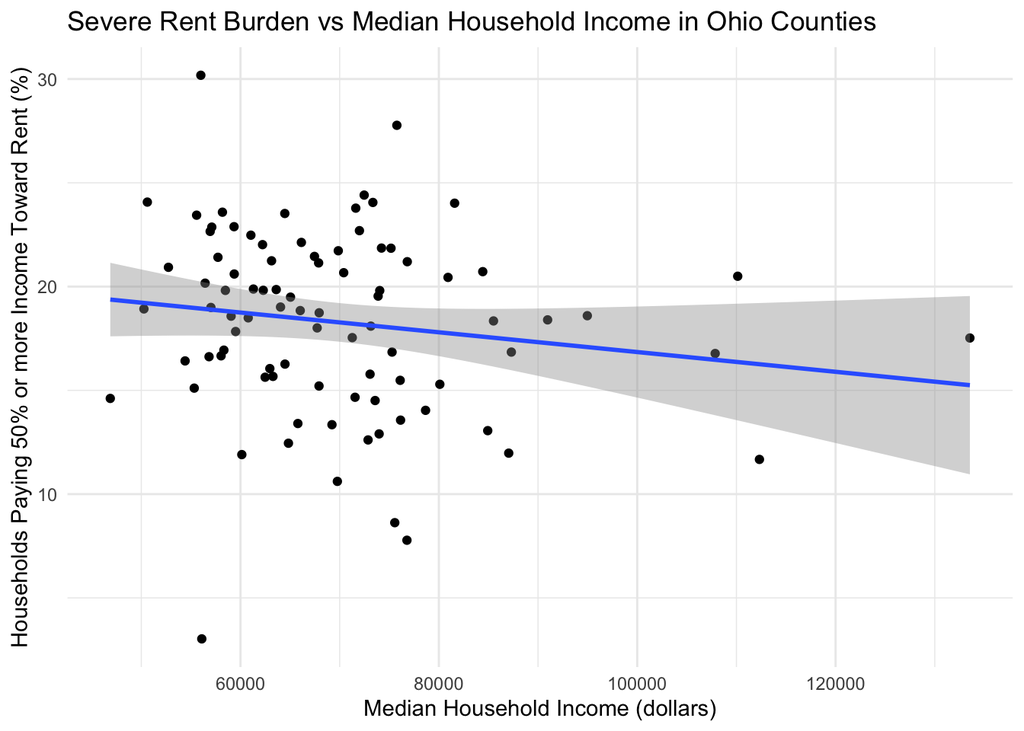

```r
library(ggplot2)
ggplot(ohio_counties, aes(x=median_household_incomeE,
                          y=severe_burden_rate))+
  geom_point()+
  geom_smooth(method = "lm", se= TRUE)+
  labs(
    title = "Severe Rent Burden vs Median Household Income in Ohio Counties",
    x = "Median Household Income (dollars)",
    y = "Households Paying 50% or more Income Toward Rent (%)"
  )+
  theme_minimal()
```

The code creates a scatter plot with the request x and y and a regression line to show any treads between burden rate of rents and median household income.

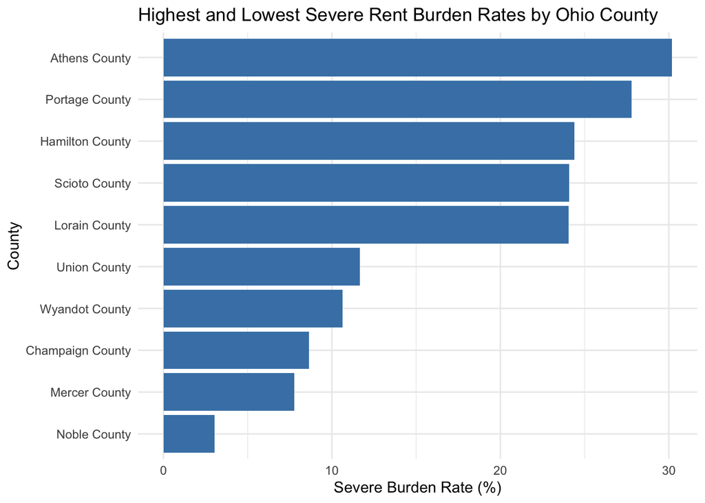

```r
ggplot(selected_counties, aes(x = reorder(county, severe_burden_rate),
                             y = severe_burden_rate)) +
  geom_col(fill = "steelblue") +
  coord_flip() +
  labs(
    title = "Highest and Lowest Severe Rent Burden Rates by Ohio County",
    x = "County",
    y = "Severe Burden Rate (%)"
  ) +
  theme_minimal()
```

This code creates a bar chart of the 10 most extreme values of the severe burden rate. I utilized the dataframe I created from the previous min and max step.

**Reflect:**  
**1:** There is no strong relationship between income and severe rent burden in Ohio. The scatterplot shows a slight decrease in severe rent burden among higher income households as the regression line decreases along the x-axis. However, the decrease is very small and the line does not seem well fit.

**2:** The limitations of using county-level ACS estimates to decide where to target rental assistance is that the data is very broad and doesn’t account for other factors of rent-burden. There could be other reasons such as housing availability and rent prices that driven rent burdens instead of income. This data is limited in that it cannot provide market research but only demographics.

## Part V

**1:** If I wanted to publish a map of West Town requests, residents may feel their privacy violated in that they did not consent to their requests being made public. Anyone could easily see the map and learn things about specific residents who live there. For example, an insurance company could use the map to influence the insurance rates for residents who live there. Therefore, a map containing specific addresses of the requests would need to be de-identifiable and have noise added to it. I would do this by utilizing perturbation and removing identifiers. I would remove the street_address columns and add 5% noise to obscure the data. This will help ensure use of summary statistics instead of individual records and exact value be hidden.  
**2:**A city manager can be misled by assigning repair crews to request counts because people can call in multiple requests for the same issue. One way to check is by aggregating the data. This could be done by utilizing the street_address column to group requests that have the same street_address, report date and service request so that if multiple people report the same problem to the same location, only one crew is called in to fix it. This allows the city manager to group projects and provide better accuracy for repair crews.  
**3:**The web scraping done in Part II was appropriate because the data was public and non-personable as the data for communities was about general areas. Furthermore the data regarding the books was purely factual except for the star ratings which was generalized from multiple reviews. Situations where one should not scrape without further review is when the data is not public or behind a pay-wall and there is identifiable information included. A civic data example situation would be web scraping voter information to see how many individuals living in a neighborhood are registered to vote. Even if the information is meant to help empower voters, it is an ethical and legal violation despite a well-intended goal.

**AI Use Statement:** I used DuckDuckGo ai to help me with targeted functions. I used AI to help me web scrape using the GET function as well as how to use the gsub() function and fromJSON. Those were the 3 functions I needed AI to explain to me.